# Indirect approach to optimal control of a nonlinear system on a finite time horizon

Now we finally seem to be ready for solving our optimal control problems stated at the beginning of the lecture/chapter. Equipped with the solution to the fixed-ends basic problem of calculus of variation, we start with the finite-horizon fixed-final-state version of the optimal control problem. We will extend the result for a free final state in due course.

## Continuous-time optimal control problem

The problem to be solved is

$$\begin{aligned}
\operatorname*{minimize}_{\bm x(\cdot),\bm u(\cdot)} &\quad \int_{t_\mathrm{i}}^{t_\mathrm{f}}L(\bm x(t),\bm u(t),t)\text{d}t\\
\text{subject to} &\quad \dot{\bm x}(t)= \mathbf f(\bm x(t),\bm u(t),t),\\
&\quad \bm x(t_\mathrm{i}) = \mathbf x_\mathrm{i},\\
&\quad \bm x(t_\mathrm{f}) = \mathbf x_\mathrm{f}.
\end{aligned}$$

There is, of course, no term in the cost function penalizing the state at the final time since it is requested that the system is brought to some prespecified state.

## First-order necessary conditions of optimality

The augmented cost function is
$$J^\mathrm{aug}(t,\bm x(\cdot),\dot{\bm x}(\cdot),\bm u(\cdot),\bm\lambda(\cdot)) = \int_{t_\mathrm{i}}^{t_\mathrm{f}}\left[\underbrace{ L(\bm x,\bm u,t)+\bm\lambda^\top\left(\mathbf f(\bm x,\bm u,\mathbf t)-\dot {\bm x}\right)}_{L^\text{aug}}\right ]\text{d}t,
\tag{1}$$
in which we have also identified the augmented Lagrangian
$$L^\text{aug}(\bm x,\bm u,\dot{\bm x},\bm\lambda,t) = L(\bm x,\bm u,t)+\bm\lambda^\top\left(\mathbf f(\bm x,\bm u,\mathbf t)-\dot {\bm x}\right).
\tag{2}$$

Note also that compared to the original unconstrained calculus of variations setting, here we made a notational shift from $x$ to $t$ as the independent variable, and from $y$ to the triplet $(\bm x,\bm u,\bm \lambda)$ as the triplet of dependent variables (possibly vector ones). Finally, note that the only derivative appearing in the augmented Lagrangian is $\dot{\bm x}$.

### Boundary value problem (BVP) as the necessary conditions of optimality

Applying the Euler-Lagrange equation to this augmented Lagrangian, we obtain three equations (or three systems of equations), one for each dependent variable:

$$\begin{aligned}
L_{\bm{x}}^\text{aug} &= \frac{\text{d}}{\text{d}t} L^\text{aug}_{\dot{\bm{x}}},\\
L_{\bm{u}}^\text{aug} &= 0,\\
L_{\bm \lambda}^\text{aug} &= 0.
\end{aligned}
\tag{3}$$

These can be expanded in terms of the unconstrained Lagrangian. First, we assume scalar functions for notational simplicity:
$$\begin{aligned}
\frac{\partial L}{\partial x} + \lambda \frac{\partial f}{\partial x}&= -\dot{\lambda},\\
\frac{\partial L}{\partial u} + \lambda \frac{\partial f}{\partial u} &= 0,\\
f(x,u,t) - \dot {x} &= 0.
\end{aligned}$$

In the vector case (wherein $\bm x$, hence $\mathbf f()$, and/or $\bm u$ are vectors):
$$\begin{aligned}
\nabla_{\bm{x}} L + \sum_{i=1}^n \lambda_i \nabla_{\bm{x}} f_i(\bm x, \bm u) &= -\dot{\bm{\lambda}},\\
\nabla_{\bm{u}} L + \sum_{i=1}^n \lambda_i \nabla_{\bm{u}} f_i(\bm x, \bm u) &= \mathbf 0,\\
\mathbf{f}(\bm x,\bm u,t) - \dot{\bm{x}} &= \mathbf 0.
\end{aligned}$$

We can also write the same result in the compact vector form. Recall that we agreed in this course to regard gradients as column vectors and that $\nabla \mathbf f$ for a vector function $\mathbf{f}$ is a matrix whose columns are gradients $\nabla_\mathbf{x} f_i$ of the individual elements of the vector function. We can then write the first order conditions compactly as
$$\begin{aligned}
\nabla_\mathbf{x}L + \nabla_\mathbf{x} \mathbf{f} \; \bm\lambda &= -\dot{\bm\lambda},\\
\nabla_\mathbf{u}L + \nabla_\mathbf{u} \mathbf{f} \; \bm\lambda &= \mathbf 0,\\
\mathbf{f}(\bm x,\bm u,t) - \dot {\mathbf{x}} &= \mathbf 0.
\end{aligned}$$

After reordering the equations and shuffling the terms within the equations, we get
$$\boxed{
\begin{aligned}
\dot {\mathbf{x}}(t) &= \mathbf{f}(\bm x(t),\bm u(t),t),\\
-\dot{\bm\lambda}(t) &= \nabla_\mathbf{x}L(\bm x(t),\bm u(t),t) + \nabla_\mathbf{x} \mathbf{f}(\bm x(t),\bm u(t),t) \, \bm\lambda(t),\\
\mathbf 0 &= \nabla_\mathbf{u}L(\bm x(t),\bm u(t),t) + \nabla_\mathbf{u} \mathbf{f}(\bm x(t),\bm u(t),t) \, \bm\lambda(t).
\end{aligned}}
\tag{4}$$

These three (systems of) equations give the necessary conditions of optimality that we were looking for. We can immediately recognize the first one – the original state equation describing how the *state* vector variable $\bm{x}$ evolves in time.

The other two equations are new, though. The second one is called *costate equation* because the variable $\bm\lambda$, originally introduced as a Lagrange multiplier, now evolves also according to a first-order differential equation; we call it a *costate* variable.

The last equation is called *equation of stationarity*. Unlike the previous two, it is not a differential equation, it is just a nonlinear equation. With the exception of some singular cases that we are going to mentions soon, it can be be solved for the control vector $\bm u$ as a function of the state $\bm x$ and the costate $\bm \lambda$, in which case $\bm u$ can be eliminated from the two differential equations and we end up with differential equations just in $\bm{x}$ and $\bm\lambda$.

### Boundary conditions

Recall that for differential equations we always need a sufficient number of boundary conditions to determine the solution uniquely. In particular, for a state vector of dimension $n$, the costate is also of dimension $n$, hence we need in total $2n$ boundary conditions. In our current setup these are given by the $n$ specified values of the state vector at the beginning and $n$ values at the end:
$$\boxed{
\begin{aligned}
&\quad \bm x(t_\mathrm{i}) = \mathbf x_\mathrm{i},\\
&\quad \bm x(t_\mathrm{f}) = \mathbf x_\mathrm{f}.
\end{aligned}}
\tag{5}$$

Only after these equations are added to the above DAE systems, we have a full set of necessary conditions of optimality.

This class of problems is called *two-point boundary value problem* (BVP) and generally it can only be solved numerically (dedicated solvers exist, see the section on software).

### First-order necessary conditions of optimality using the Hamiltonian function

We now introduce an auxilliary function called *Hamiltonian*, which not only makes the conditions of optimality even more compact, but also – and even more importantly – it strengthens the link with the physics-motivated calculus of variations. We expand the definition of the augmented Lagrangian
$$\begin{aligned}
L^\mathrm{aug}(\bm x,\bm u,\bm \lambda,t) &= L(\bm x,\bm u,t)+\bm \lambda^\top\left(\mathbf f(\bm x,\bm u,\mathbf t)-\dot {\bm x}\right)\\
&= L(\bm x,\bm u,t)+\bm \lambda^\top \mathbf f(\bm x,\bm u,\mathbf t) - \bm \lambda^\top \dot {\bm x}.
\end{aligned}
\tag{6}$$
and label the first two terms as $H(\bm x,\bm u,\bm\lambda,t)$, that is, we define
$$\boxed{
H(\bm x,\bm u,\bm\lambda,t) \coloneqq L(\bm x,\bm u,t)+\bm \lambda^\top \mathbf f(\bm x,\bm u,\mathbf t).}
\tag{7}$$

Using this new function, the necessary conditions of optimality in Eq. 4 can be rewritten in a more compact form:
$$\boxed{
\begin{aligned}
\dot {\mathbf{x}} &= \nabla_{\bm \lambda} H(\bm x,\bm u,\bm \lambda, t),\\
\dot{\bm\lambda} &= - \nabla_{\bm x} H(\bm x,\bm u,\bm \lambda,t),\\
\mathbf 0 &= \nabla_\mathbf{u}H(\bm x,\bm u,\bm \lambda,t).
\end{aligned}}
\tag{8}$$

Of course, we must not forget to add the boundary conditions Eq. 5 to have a full set of necessary conditions of optimality.

Now, I promised some connection with the (physics-motivated) calculus of variations. Recall that the Hamiltonian function in the calculus of variations is defined as $H(x,y,y',p) = py'-L$. At first sight, this does not seem to resemble the function we have just defined in Eq. 7 for optimal control. First, the control Hamiltonian does not explicitly depend on the derivative of any function. But realizing that through the state equation $\dot{\bm x}=\mathbf f(\bm x,\bm u, t)$, the derivative $\dot{\bm x}$ at a given state $x$ (and time $t$) is uniquelly determined by $u$, we can consider the control-related Hamiltonian as a function of just $t, \mathbf x, \mathbf u$ and $\bm\lambda$ (and discard the $\dot{\bm x}$ argument). Second, in the optimal control setting we consider constraints in the form of the state equation, hence we need to use the augmented Lagrangian, which is related to the Hamiltonian function as
$$H(\bm x,\bm u,\bm \lambda, t) = \bm \lambda^\top\dot {\bm x} + L^\mathrm{aug}(\bm x,\bm u,\bm \lambda,t).$$

This is nearly it, barring the sign in front of the Lagrangian (and that the new independent variable is $t$ while it was $x$ in the calculus of variations, and that the new dependent variables are $\bm x$ and $\bm u$ and $\bm \lambda$, the latter playing the the role of $p$, is perhaps obvious). We could leave it at it, with the comment that the optimal control has just a different sign convention.

But if you want to dig deeper, note that our choice of the constraint function in the augmented Lagrangian Eq. 2 was somewhat arbitrary – we could have defined it as $\dot {\bm x}-\mathbf f(\bm x,\bm u,\mathbf t)$ instead of $\mathbf f(\bm x,\bm u,\mathbf t)-\dot {\bm x}$, which would have resulted in a different augmented Lagrangian, namely
$$\tilde L^\mathrm{aug}(\bm x,\bm u,\bm \lambda,t) = L(\bm x,\bm u,t)+\bm \lambda^\top\left( \dot {\bm x}-\mathbf f(\bm x,\bm u,\mathbf t)\right).$$

If we now defined the Hamiltonian function as
$$\tilde H(\bm x,\bm u,\bm\lambda,t) \coloneqq \bm\lambda^\top \mathbf f(\bm x,\bm u,t) - L(\bm x,\bm u,t),
\tag{9}$$
we could relate it to the augmented Lagrangian as
$$\tilde H(\bm x,\bm u,\dot{\bm{x}},\bm\lambda,t) = \bm\lambda^\top \, \dot{\bm x} - \tilde L^\text{aug},$$
whis now matches the structure of the Hamiltonian even more closely. But this is all just a matter of a sign convention, and the fact is that the former definition of the control Hamiltonian in Eq. 7 is more common in the optimal control literature, so we stick to it.

**Example 1 (Pendulum swingup problem approached as an optimal control problem and solved as a two-point boundary value problem)** We consider a pendulum on a horizontally moving cart. The only control input is the reference acceleration of the cart – it is assumed that a feedback controller is already implemented that tracks this reference acceleration. The resulting model of dynamics is
$$\ddot \theta = \frac{\mathrm g}{l}\sin\theta + \frac{1}{l}\cos\theta \;u,$$
where $u$ is the reference acceleration of the cart, $l$ is the length of the pendulum, and $g$ is the gravitational constant, $\theta(t)$ is the angular deviation from the upright vertical, positive in the counterclockwise direction.

The pendulum is initially at rest in the downward vertical position, that is, $\bm x(0) = \begin{bmatrix}\pi\\ 0\end{bmatrix}$. The desired final state is $\bm x(t_\mathrm{f}) = \begin{bmatrix}0\\ 0\end{bmatrix}$, that is, the pendulum should be upright and at rest. The final time $t_\mathrm{f}$ is fixed, we must specify it before solving the optimal control problem (in the next chapter we will learn how to consider it an optimization variable too).

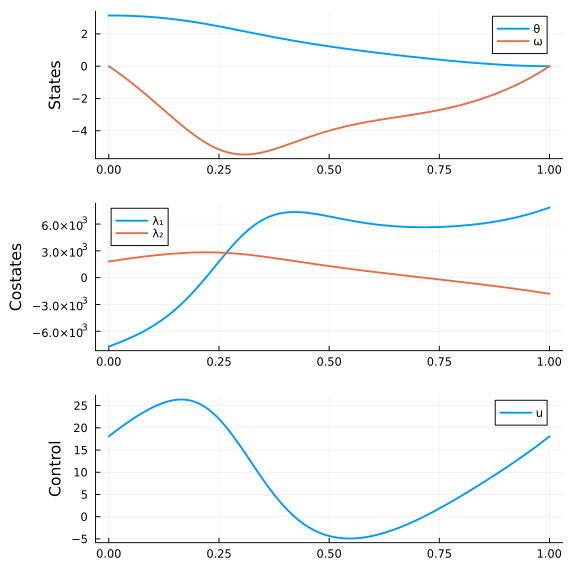

Figure 1: Optimal trajectories of state, costate and control for the pendulum swingup problem.

```julia
using BoundaryValueDiffEq
function pendulum_swingup_bvp()
    g = 9.81                                                        # Gravitational acceleration.
    l = 1.0                                                         # Length of the pendulum.
    q = [1.0, 1.0]                                                  # State weights.
    r = 100.0                                                       # Control weight.
    #f(x,u) = [x[2]; g/l*sin(x[1]) + 1/l*cos(x[1])*u]
    #L(x,u) = 1/2(q[1]*x[1]^2 + q[2]*x[2]^2 + u^2)
    #H(x,u,λ) = L(x,u) + λ[1]*f(x,u)[1] + λ[2]*f(x,u)[2]
    tinit = 0.0                                                     # Initial time.
    tfinal = 1.0                                                    # Final time.
    xinit = [pi, 0.0]                                               # Initial state.
    xfinal = [0.0, 0.0]                                             # Final state.
    function statecostateeq!(dw, w, p, t)
        x = w[1:2]                                                  # State vector [θ, ω].
        λ = w[3:4]                                                  # Costate vector.
        u = -1/(r*l)*cos(x[1])*λ[2]                                 # Optimal control from the stationarity equation.
        dw[1] = x[2]                                                # State equation 1.
        dw[2] = g/l*sin(x[1]) + 1/l*cos(x[1])*u                     # State equation 2. Damping: - b/(m*l^2)*x[2]
        dw[3] = -q[1]*x[1] -( g/l*cos(x[1]) - 1/l*sin(x[1])*u)*λ[2] # Costate equation 1.
        dw[4] = -q[2]*x[2] - λ[1]                                   # Costate equation 2.
    end
    function bc!(res, w, p,t)
        res[1:2] = w(tinit)[1:2] - xinit
        res[3:4] = w(tfinal)[1:2] - xfinal
    end
    w0 = [xinit[1], xinit[2], 0.0, 0.0]                             # Guess at the initial state and costate.
    tspan = (tinit, tfinal)                                         # Initial and final time.
    bvprob = BVProblem(statecostateeq!, bc!, w0, tspan)
    sol = solve(bvprob, MIRK4(), dt=0.05)                           # Solve the BVP.
    u = -1/(r*l)*cos.(sol[1,:]).*sol[4,:]
    return sol.t, sol[1:2,:], sol[3:4,:], u
end
t, x, λ, u = pendulum_swingup_bvp()
using Plots
p1 = plot(t, x', ylabel="States", label=["θ" "ω"], lw=2)
p2 = plot(t, λ', ylabel="Costates", label=["λ₁" "λ₂"], lw=2)
p3 = plot(t, u, ylabel="Control", label="u", lw=2)
plot(p1, p2, p3, layout=(3,1), size=(600, 600))
```

Back to top